# Section Assignment 9

3/5/25

Things-to-Note: - 1) Don’t rename external files or edit them in any way 2) Don’t change the variable names 3) Don’t destroy or overwrite any variables 4) Don’t use global path in your script. Instead use “setwd()” interactively in the console, but don’t include this code in your submission 5) All of your figures need to be made in ggplot()

If you don’t take above instructions into account it might effect your grades. *** Your Information:

```r
firstname <- "Zakir"   # example: "Liam"
lastname <- "Alibhai"  # example: "Mueller"
username <- "zalibhai"  # example: "lomueller"   Do not include the "@ucsd.edu" part!
```

Please Read!

This week we are getting you closer to performing your final project. This week, you will need to make decisions about your data, and likely will need to do more than one line of code for each question. Start with the scenario and consider the appropriate statistical model.

Scenario:

A molecular biologist is interested in how the downregulation of the O6-alkylguanine DNA alkyltransferase gene (MGMT) is related to tumor size in mice. Available to them are 25 treatment mice, and 25 mutant mice which have downregulated MGMT.

Work carefully this week, as your assignment will influence how you answer the theory check this weekend.

You will find the data from their study in the “Week9Mice.csv” file on Canvas.

Since we have already downloaded and installed the necessary packages, this week, simply load the tidyverse functions into your working library:

Question 1: Import the data you downloaded from canvas this week and make it tidy. If it is already tidy, leave it as is, if not, make sure the MiceData object is tidy. That is the object being graded.

```r
WideData<-read.csv(file = "Week9Mice.csv")
MiceData<-pivot_longer(WideData, cols = 1:2, names_to = "miceGroup", values_to = "tumorSize")
head(MiceData)
```

```
## # A tibble: 6 × 2
##   miceGroup     tumorSize
##   <chr>             <dbl>
## 1 Downregulated      21.2
## 2 Control            19.0
## 3 Downregulated      19.7
## 4 Control            18.8
## 5 Downregulated      20.8
## 6 Control            17.7
```

```r
### This chunk of code is for grading purposes.
### Don't change/delete this chunk of code.
q1 <- MiceData
```

Question 2-3: Use visualizations and tests to determine that the data meet the appropriate assumption of normality. You must make your visualizations for this assignment in ggplot

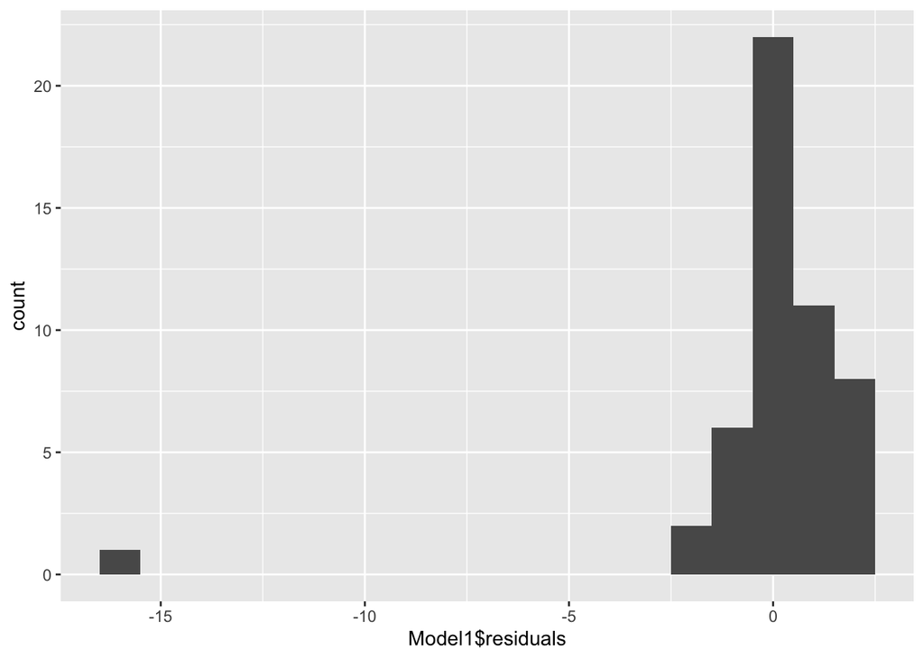

```r
Model1<-lm(tumorSize ~ miceGroup, data = MiceData)
#MiceData2<- WideData |> mutate(delta = WideData$DownRegulated - WideData$Control)
Histogram1<-ggplot(data = Model1, mapping = aes(x = Model1$residuals)) +
  geom_histogram(binwidth = 1)
Histogram1
```

```r
kstest_result<-ks.test(Model1$residuals,"pnorm",mean(Model1$residuals),sd(Model1$residuals))
kstest_result
```

```
##
##  Exact one-sample Kolmogorov-Smirnov test
##
## data:  Model1$residuals
## D = 0.25467, p-value = 0.002399
## alternative hypothesis: two-sided
```

```r
### This chunk of code is for grading purposes.
### Don't change/delete this chunk of code.
q2 <- Histogram1
q3 <- kstest_result
```

Question 4: Fix any issues you identified in the data in this section. If you think an outlier is the issue, remove that individual from the study data. If you think a transformation is needed, try a log transformation this time. If you think the raw data meet the assumptions of the model, just reassign the original data to the new name.

```r
#Fix the data if it needs fixing. Either way, use the data object generated here for future questions
#TransformedData<-MiceData |> mutate(tumorSize = log(MiceData$tumorSize))
which.max(cooks.distance(Model1))
```

```
## 38
## 38
```

```r
#ORData<-TransformedData[-38,]
#W9Data<-ORData
W9Data<-MiceData[-38,]
W9Data
```

```
## # A tibble: 49 × 2
##    miceGroup     tumorSize
##    <chr>             <dbl>
##  1 Downregulated      21.2
##  2 Control            19.0
##  3 Downregulated      19.7
##  4 Control            18.8
##  5 Downregulated      20.8
##  6 Control            17.7
##  7 Downregulated      19.4
##  8 Control            17.8
##  9 Downregulated      19.7
## 10 Control            17.8
## # ℹ 39 more rows
```

```r
### This chunk of code is for grading purposes.
### Don't change/delete this chunk of code.
q4 <- W9Data
```

Question 5: Generate a linear model to model the relationship in the data. You may have already built one above, but if you changed anything about your data it needs to be remade. Either way it needs to be here as well.

```r
#Build your linear model in this code block
Model2<-lm(tumorSize ~ miceGroup, data = W9Data)
Histogram2<-ggplot(data = Model2, mapping = aes(x = Model2$residuals)) +
  geom_histogram(binwidth = 1)
kstest2<-ks.test(Model2$residuals,"pnorm",mean(Model2$residuals),sd(Model2$residuals))
q5 <- Model2
q5
```

```
##
## Call:
## lm(formula = tumorSize ~ miceGroup, data = W9Data)
##
## Coefficients:
##            (Intercept)  miceGroupDownregulated
##                 18.102                   1.698
```

Question 6: Now that you have the slope and intercept estimates for your model, write out the linear equation that predicts Y. Use the column names for X and Y

```r
q6 <- "tumorSize = 1.698(miceGroupDownregulated) + 18.102"
```

Question 7: What is the r squared value of your model? You may calculate it however you want, but q7 needs to just have the single number assigned to it.

```r
summary(Model2)
```

```
##
## Call:
## lm(formula = tumorSize ~ miceGroup, data = W9Data)
##
## Residuals:
##      Min       1Q   Median       3Q      Max
## -2.68342 -0.44242 -0.00677  0.74268  1.93457
##
## Coefficients:
##                        Estimate Std. Error t value Pr(>|t|)
## (Intercept)             18.1024     0.1973  91.745  < 2e-16 ***
## miceGroupDownregulated   1.6980     0.2762   6.147 1.61e-07 ***
## ---
## Signif. codes:  0 '***' 0.001 '**' 0.01 '*' 0.05 '.' 0.1 ' ' 1
##
## Residual standard error: 0.9666 on 47 degrees of freedom
## Multiple R-squared:  0.4457, Adjusted R-squared:  0.4339
## F-statistic: 37.79 on 1 and 47 DF,  p-value: 1.612e-07
```

```r
q7 <- 0.4457 #Type your answer to the left of this hashtag so it assigns q7 the correct value.
```

Question 8: Perform the appropriate null hypothesis test for your research question. Hint, be careful about correct degrees of freedom! q8 should be an r output object from a function that tests null hypotheses. The correct p value should be part of this object, but not the entire output.

```r
q8 <-t.test(W9Data$tumorSize~W9Data$miceGroup)
q8
```

```
##
##  Welch Two Sample t-test
##
## data:  W9Data$tumorSize by W9Data$miceGroup
## t = -6.1426, df = 46.728, p-value = 1.672e-07
## alternative hypothesis: true difference in means between group Control and group Downregulated is not equal to 0
## 95 percent confidence interval:
##  -2.254238 -1.141831
## sample estimates:
##       mean in group Control mean in group Downregulated
##                    18.10241                    19.80044
```

Question 9: Generate a figure representing the data and model. I am not giving you a template this time, so be thoughtful about the kinds of figures we have made and the choices we have made to improve them.

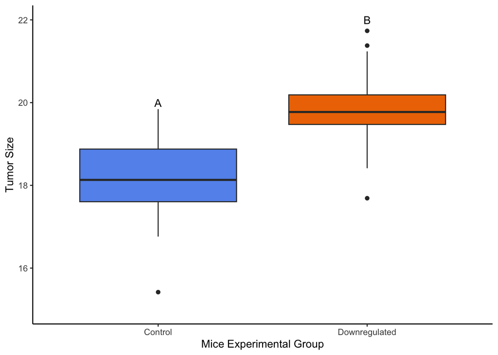

```r
plot1<-ggplot(data=W9Data,mapping=aes(x=miceGroup,y=tumorSize,fill=miceGroup)) +
  theme_classic() +
  coord_cartesian(ylim=c(15,22)) +
  scale_fill_manual(values = c("cornflowerblue", "darkorange2"))+
  xlab("Mice Experimental Group") +
  ylab("Tumor Size") +
  annotate(geom="text",x=c("Control","Downregulated"),y=c(20,22),label=c("A","B"))+
  guides(fill="none")+
  geom_boxplot()
plot1
```

```r
### This chunk of code is for grading purposes.
### Don't change/delete this chunk of code.
q9 <- plot1
```

Once you are done, make sure there are no errors in the knit. Save the .rmd file with your name and the week number in the file name:

(for example: “Liam_Mueller_Section_Assignment_9.rmd”).

Then upload this rmd file to canvas under the Week 9 module before the deadline.